# **Analysis On Google Play Store Apps**

Snehitha Tadapaneni, Sai Rachana Kandikattu, Amrutha Jayachandradhara, Wilona Nguyen, Pramod Krishnachari

2024-12-16

# **Introduction**

In the fast-paced and competitive world of mobile applications, understanding what makes an application successful is a pressing challenge for developers, businesses, and researchers alike. With Android dominating the mobile operating system landscape—powering over 2.5 billion active devices globally (Brandom, 2019)—the Google Play Store has become the central hub for app distribution and user engagement. Offering millions of applications across diverse categories, the platform serves as an invaluable resource for analyzing user behavior and preferences.

The key to an app’s success lies in understanding the intricate relationships between various features, such as app category, ratings, reviews, content suitability, and technical compatibility. Identifying patterns within these factors enables developers to design apps that align with user expectations, thereby increasing downloads, engagement, and retention rates. In this project, we leverage the comprehensive dataset from the Google Play Store to predict app success based on these features.

To address this problem, we have adopted a robust machine learning approach, employing and comparing multiple classification models, including Logistic Regression, k-Nearest Neighbors (kNN), Random Forest, Support Vector Machines (SVM), and Extreme Gradient Boosting (XGBoost). By systematically evaluating the performance of these models, we aim to determine the most effective classifier for predicting app success.

This analysis not only provides actionable insights for app developers and stakeholders but also contributes to the broader understanding of user dynamics and preferences in the app ecosystem. Through this research, we aim to bridge the gap between user expectations and app design, empowering developers to make data-driven decisions that enhance user satisfaction and engagement.

# **Exploratory Data Analysis (EDA)**

## Dataset Overview

The dataset used in this study is a popular collection of Google Play Store apps, sourced from Kaggle (faisaljanjua0555, 2023). It contains detailed information about 10,841 apps, organized across 13 variables, with each row representing an individual app. The dataset covers a range of app attributes, such as ratings, reviews, size, category, installs, price, and content rating, providing valuable insights into the characteristics that contribute to app popularity and user engagement. This comprehensive data serves as a foundation for analyzing patterns in user behavior, app performance, and trends within the mobile app ecosystem.

## Data Cleaning

The Google Play Store dataset, as analyzed, contains missing values and inconsistent formats across various columns. To clean and prepare this dataset for analysis, several steps were taken to address these data quality issues. Here is an overview of how missing records were managed and further improvements that could be considered:

- Duplicates: Removed 1,181 duplicate apps, reducing the dataset from 10,841 to 9,660 unique apps to eliminate redundancy.
- Price: Cleaned dollar symbols for numeric conversion and removed rows with missing or blank prices.
- Type: Replaced one missing value with “Free” based on a logical inference.
- Size: Standardized sizes (KB/MB) and replaced “Varies with device” entries with mean sizes by category.
- Installs: Removed symbols (+, commas) and cleaned non-numeric entries for numeric conversion.
- Rating & Reviews: Imputed 1,463 missing ratings with category-wise means; converted reviews to integer format.
- Last Updated: Standardized date format for accuracy.
- Category & Genres: Retained Category while removing redundant Genres for clarity.
- Current Version: Excluded due to inconsistencies across records.
- Android Version: Removed two rows with ‘NaN’ values.

Additional Transformations:

- Review & Install Categories: Binned data for balanced representation across reviews and installs.
- Log Transformed Installs: Applied log transformation to normalize install data and reduce skewness.
- Update Category: Classified updates as “Old” or “Recent” to analyze the impact on performance metrics.

## Data Visualizations

**Figure 1**. Installs vs Category

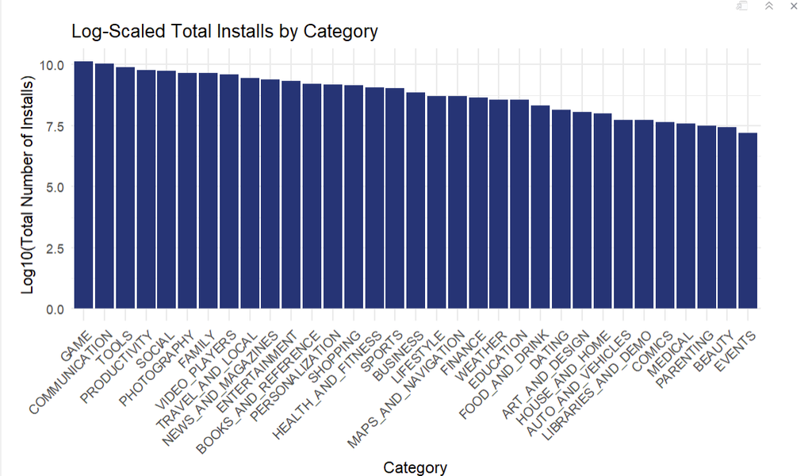

From Figure 1, it could be observed that the top 5 categories having highest Installs are Game, Communication, Tools, Productivity, Social.

**Figure 2**. Installs vs Reviews

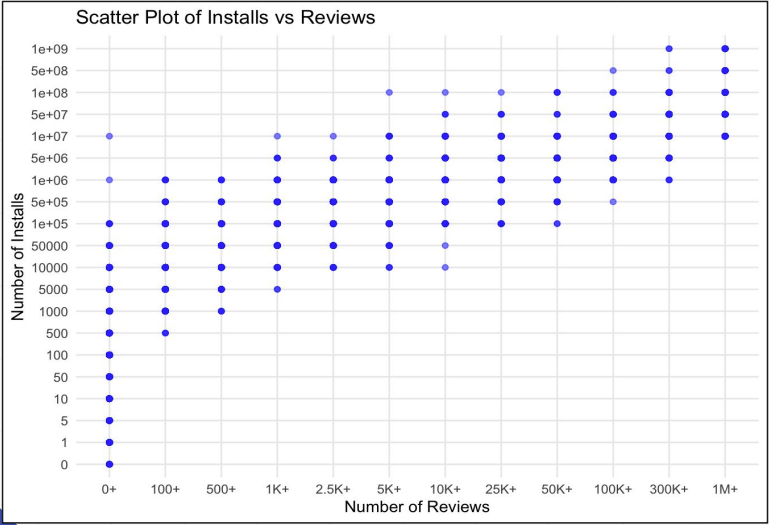

From Figure 2, It is evident that for higher Reviews the installs range is higher, indicating higher Installs for higher Reviews.

**Figure 3**. Installs vs Rating

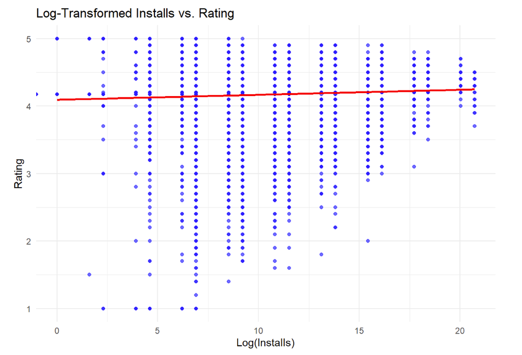

From Figure 3, It could be seen that for high installs the ratings are clustered in the higher range

**Figure 4**. Installs vs Price

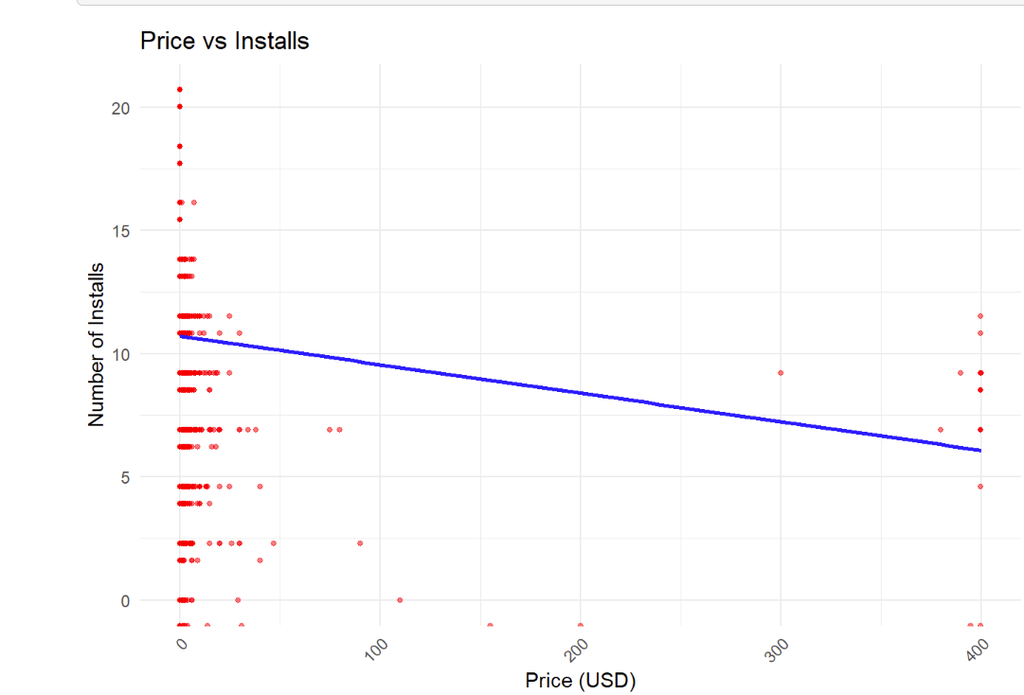

From Figure 4, The installs are higher for apps which are free and decrease in installs as the price increases, indicating better to have a free app for high installs.

# **Data Pre-processing**

- *Category Encoding*  
  The Category column was transformed into dummy variables using model.matrix(), and the original column was removed. Column names were standardized by replacing spaces with underscores.
- *Installs Classification*  
  The Installs column was converted into a binary variable (Low Installs as 0 and High Installs as 1) based on the median value. A histogram was created to visualize the distribution of categories.
- *Last Updated Transformation*  
  The Last.Updated column was converted into numeric values representing the days since the most recent update, ensuring a quantitative measure of recency.

# **SMART Question**

> **Which are the top 5 app categories, as identified by classification models (logistic regression, SVM, XGBoost, KNN, and random forest), that significantly influenced app success (measured by installs) based on app data from 2010 to 2018, and how accurately can these models predict success trends within this time period?**

# **Model Development Process**

## Logistic Regression

### Why Logistic Regression?

The Logistic Regression model is considered because it is an interpretable model commonly used for classification tasks. In this project, the target variable is binary (Low or High Installs). It estimates the probability of an outcome, providing clear insights into the relationship between predictors and the target variable through interpretable coefficients. Additionally, logistic regression performs well with proper preprocessing and effectively handles multicollinearity and feature selection using regularization techniques. While it may not be ideal for capturing complex, non-linear relationships, logistic regression serves as a strong baseline for this problem.

### Advantages

Logistic regression is a simple yet powerful statistical method widely used for binary classification tasks. It is easy to implement, computationally efficient, and highly interpretable, as its coefficients indicate the influence of predictors on the target variable. Logistic regression provides probabilistic outputs, making it ideal for threshold-based decision-making and ranking. It works well with small datasets, is robust to multicollinearity, and does not require predictors to be normally distributed or linearly related to the target. The model supports regularization techniques like L1 and L2 to address overfitting and perform feature selection. Additionally, it serves as an excellent baseline for benchmarking classification problems and can be extended to handle multi-class and ordered outcomes. With wide applicability across fields such as medicine, finance, and marketing, logistic regression remains a fundamental tool for predictive modeling.

### Model Evaluation

#### 1. Confusion Matrix

The confusion matrix in Figure 5 shows that the model correctly classified 5763 instances of class 0 and 4580 instances of class 1, with 370 false positives and 127 false negatives. The overall accuracy is 95.42%, indicating a high proportion of correct predictions, with a 95% confidence interval of (95.0%, 95.8%). The model achieves a Kappa statistic of 0.9072, reflecting strong agreement beyond chance. Sensitivity (recall for class 0) is 97.84%, and specificity (ability to identify class 1) is 92.53%, showing balanced performance. Positive predictive value (precision for class 0) is 93.97%, and negative predictive value (precision for class 1) is 97.30%. The balanced accuracy, accounting for both sensitivity and specificity, is 95.18%. The McNemar’s test p-value (<2.2e-16) suggests significant differences between misclassifications, and the prevalence of class 0 is 54.34%.

**Figure 5**. Confusion Matrix

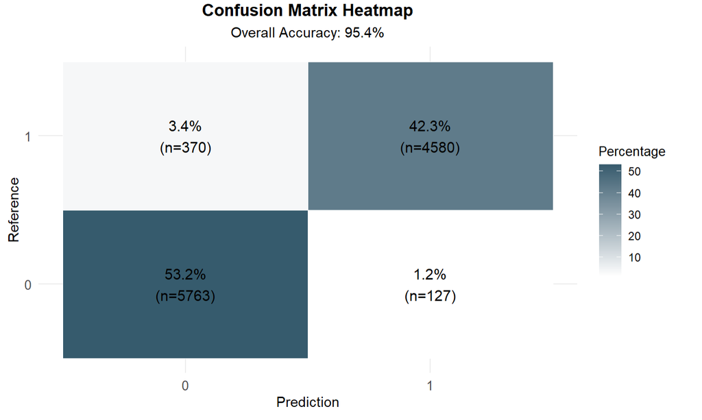

#### 2. Precision, Racall Rate, F1-Score

The model achieves a precision of 93.97%, indicating that 93.97% of the predictions for class 0 are correct. Its recall is 97.84%, meaning the model successfully identifies 97.84% of all actual class 0 instances. The F1 score, which balances precision and recall, is 95.87%, highlighting the model’s strong overall performance in accurately and consistently classifying instances of class 0. This combination of high precision and recall reflects the model’s effectiveness in minimizing both false positives and false negatives.

#### 3. ROC-AUC

The model achieves an AUC (Area Under the Curve) score of 0.9923 as seen from Figure 6, indicating excellent performance in distinguishing between classes. This demonstrates the model’s strong predictive power and effectiveness in separating class 0 and class 1 instances.

**Figure 6**. ROC-AUC Curve

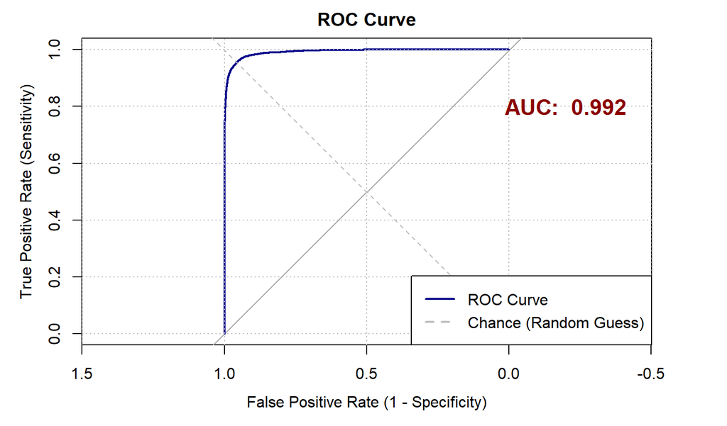

### Interpretation: Feature Importance

In Figure 7., from this stepwise model, the top five importance features from this model is: `Review`, `Price`, `Rating`, `Last.Updated`, and `Content.Rating`. The top 5 categories that have most impacted in this model is `FINANCE`, `PHOTOGRAPHY`, `EDUCATION`, `MEDICAL` and `HOUSE_AND_HOME`.

**Figure 7**. Top 10 Important Features

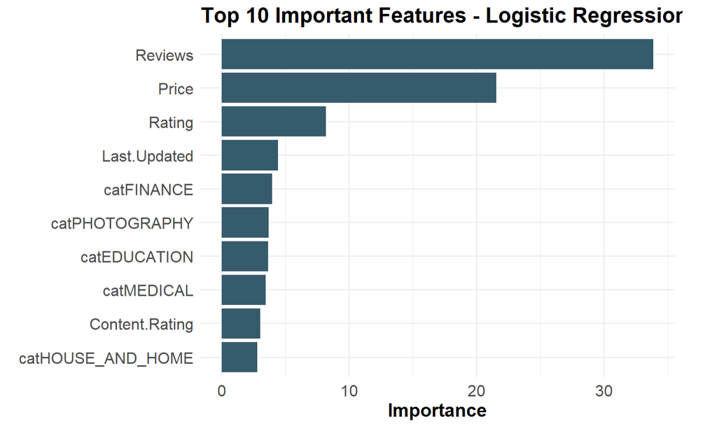

## K-Nearest Neighbors

### Why KNN?

The decision to use **K-Nearest Neighbors (KNN)** was motivated by the need to examine whether the data exhibited a **non-linear relationship** and to explore if the data could naturally form clusters rather than adhering to a linear classification boundary. KNN is particularly effective for data with non-linear patterns due to its instance-based approach, where decisions are made locally using the nearest neighbors.

### Advantages

The K-Nearest Neighbors (KNN) classifier offers several advantages that make it a popular choice for machine learning tasks. Its simplicity and ease of implementation allow for quick understanding and application. As a lazy learning algorithm, KNN does not require a training phase, making it computationally inexpensive during model building. Being non-parametric, it does not assume any specific data distribution, making it suitable for complex datasets. Additionally, KNN is versatile, supporting both classification and regression tasks, and it naturally handles multi-class problems without requiring extensive modifications. It is particularly effective for small datasets and allows for incremental learning, where new data can be incorporated without retraining the model. These characteristics make KNN ideal for scenarios requiring adaptability, interpretability, and dynamic data handling.

### Model Evaluation

#### 1. Parameters

The **KNN parameter `K`** plays a crucial role in determining the model’s performance:

- **Optimal Value of `K`**:
  - The value of `K` was optimized using a **cross-validation technique** to evaluate accuracy for different values of `K`.
  - After testing, the optimal value was found to be **`K = 7`**, having the highest accuracy
- **Distance Metric**:  
  The **Euclidean Distance** was utilized as the distance measure, as this metric calculates the straight-line distance between points in the feature space, making it suitable for continuous numerical data as most of our data is numerical data

#### 2. Confusion Matrix

**Figure 8**. Confusion Matrix

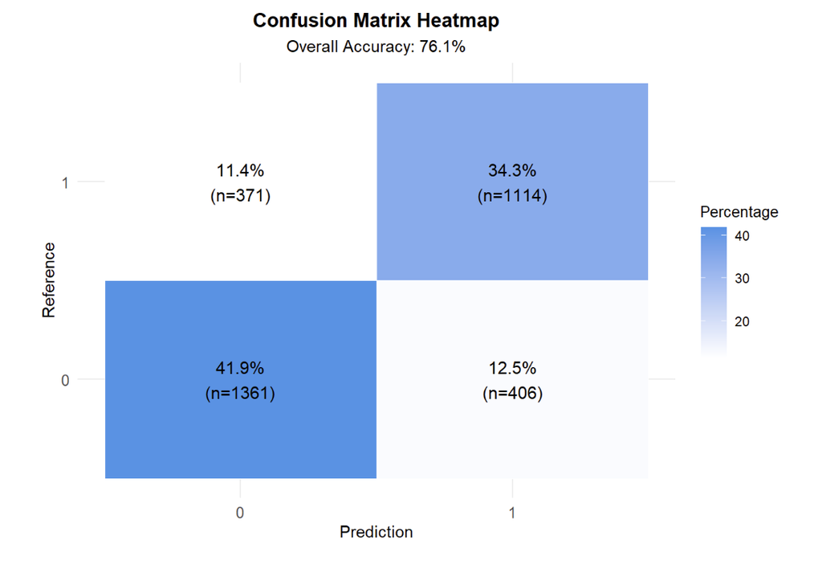

##### In Figure 8: Model Performance Summary

**Moderate Classification**: The model achieves a moderate level of accuracy with 1361 True Negatives and 1114 True Positives, indicating some success but also limitations.

**Class Imbalance Issues**: The slight imbalance between classes may hinder effective generalization, impacting the model’s predictive capabilities.

**Inconsistent Performance**: The model shows weakness in identifying class 1, as evidenced by the high False Negatives, reflecting areas for improvement.

#### 3. Precision, Recall, and F1-Score

The model achieves a precision of **78.57%**, indicating that 78.57% of the predicted instances are correct. While this is a positive indication, it falls below the desired threshold of 80%.

The overall accuracy is **76.10%**, reflecting the model’s correctness in predictions, but again, it does not meet the 80% benchmark.

The recall is measured at **77.02%**, meaning the model successfully identifies 77.02% of all actual instances, which suggests some room for improvement in capturing all relevant cases.

Finally, the F1 score, which balances precision and recall, stands at **77.79%**. This metric indicates a moderate performance level, highlighting the need for enhancements to minimize false positives and false negatives for more consistent classification.

#### 4. ROC

**Figure 9**. ROC Curve

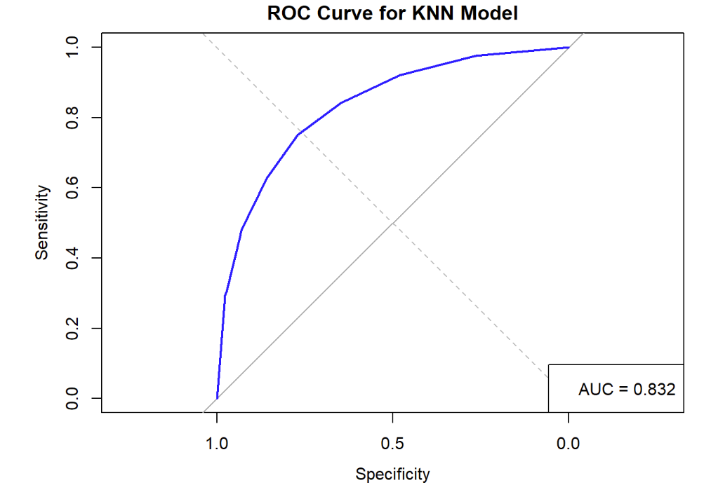

### Interpretability: Feature Importance

Apps with high installs tend to share features such as higher review counts and More frequent updates. These factors should be a focal point in marketing strategies to boost installs.

**Figure 10**. Top Categories

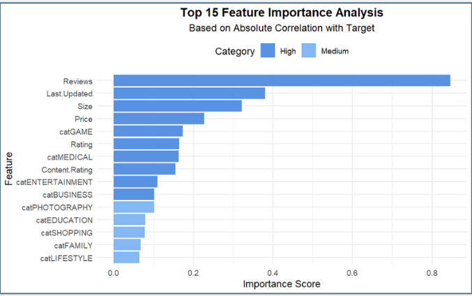

## Random Forest Classifier

### Why Random Forest?

The Random Forest classifier is considered because it is a robust and flexible model that performs well in classification tasks, such as in this project, where the target variable is binary (Low or High Installs). It combines multiple decision trees to produce a more accurate and stable prediction through an ensemble approach. Random Forest handles non-linear relationships effectively and is resistant to overfitting due to its random sampling and feature selection techniques. Additionally, it provides insights into feature importance, which can guide further analysis and feature selection.

### Modelling

The initial Random Forest model was built using all 39 variables, and its performance metrics, such as accuracy and F1-score, demonstrated its strong classification capability. To optimize the model, hyperparameter tuning was conducted to balance complexity and accuracy. Key parameters such as mtry (number of features considered at each split), ntree (number of trees in the forest), and nodesize (minimum size of terminal nodes) were fine-tuned. The tuning process evaluated mtry values of 2, 4, 6, 8, and 10, with the optimal value determined to be 4, which significantly reduced the model’s tendency to overfit. Adjusting these parameters ensured a better generalization of the model while maintaining high classification accuracy.

### Advantages

Random Forest offers several advantages that make it a strong candidate for classification tasks. It is highly robust and capable of modeling complex, non-linear relationships by aggregating results from multiple decision trees. This ensemble approach reduces the risk of overfitting, especially with proper parameter tuning. Additionally, the model provides feature importance rankings, offering insights into the predictors most relevant to the outcome. Random Forest performs well with large datasets and can handle a mix of categorical and continuous variables without requiring extensive preprocessing. Its ability to handle missing data and reduce variance through bootstrapping further enhances its reliability in predictive modeling tasks.

### Model Evaluation

#### 1. Confusion Matrix

**Figure 11**. Confusion Matrix of Random Forest

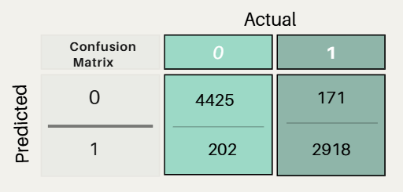

#### 2. Graph Analysis: Error Rates and Model Stability

The graph in the slide illustrates the error rates for the Random Forest model as the number of trees increases.

- *Out-Of-Bag (OOB) Error:* The black line represents the OOB error rate, which stabilizes at a low level as the model grows more trees. This indicates that adding more trees contributes to better performance without overfitting.
- *Class 1 and Class 2 Errors:* The red and green lines represent the error rates for class 1 and class 2, respectively. Both error rates decrease rapidly as the number of trees increases and stabilize, demonstrating the model’s ability to effectively classify instances of both classes. The error analysis shows that the model achieves convergence, with consistently low error rates across all classes, highlighting the reliability of the Random Forest classifier. As, per the graph, the model is pretty reliable with generalizability.

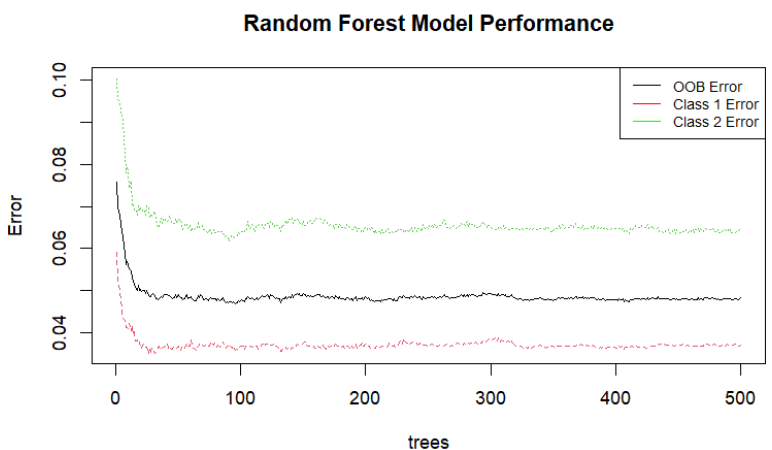

### Interpretability: Feature Importance

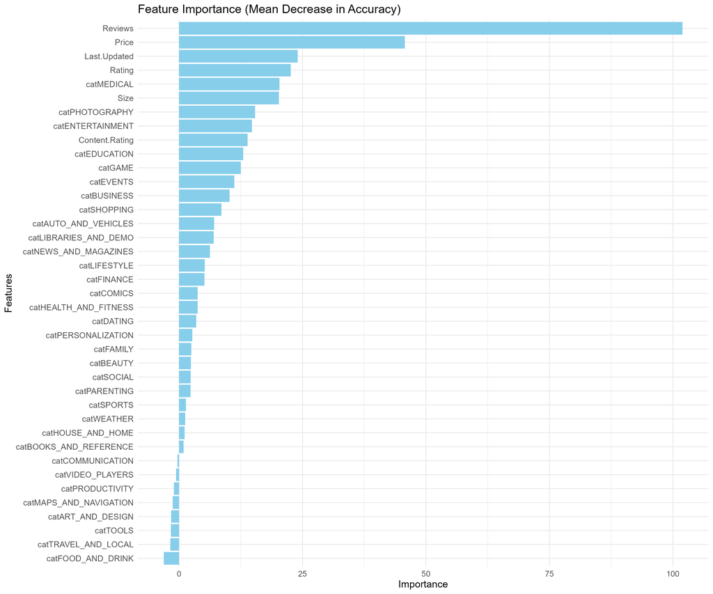

## XG Boost

### Why Gradient boost

This project utilized a gradient boosting algorithm to predict “Low Installs” vs. “High Installs” for Play Store apps. Gradient boosting was chosen for its ability to handle complex relationships, mixed data types, and imbalanced datasets, while providing feature importance insights and high predictive power.

### Modelling

After the data has been divided into 80% training data and 20% testing data.Following are the parameters for building the model:

- Objective: The model is designed for binary classification
- Evaluation metric:optimizing logloss
- max depth of 6 to control tree complexity,
- learning rate (ETA) of 0.1 for gradual training,
- subsample of 0.8 to reduce overfitting by sampling 80% of the data, and
- colsample_bytree set to 0.8 to randomize feature selection.

These settings have balanced model performance, generalization, and training stability.

### Model Evaluation

#### 1. Confusion matrix

**Figure 14**. Confusion Matrix of Gradient Boosting

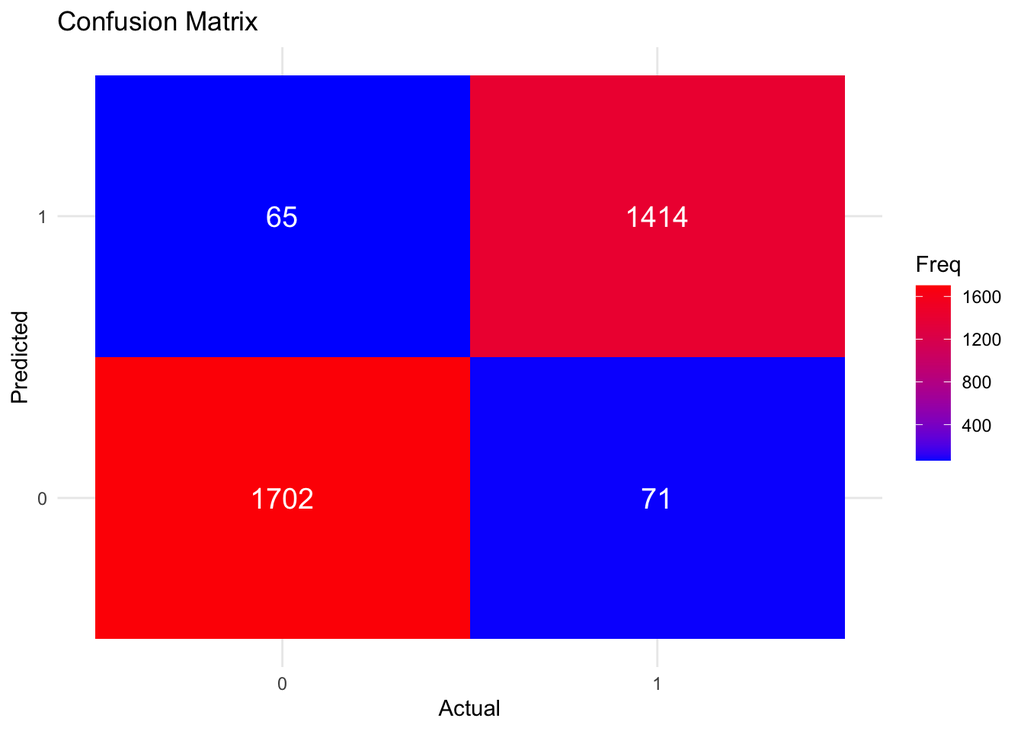

For classification tasks, Gradient Boosting models are evaluated on their ability to predict categorical labels.

#### 2. Logloss

**Figure 14**. LogLoss over iterations

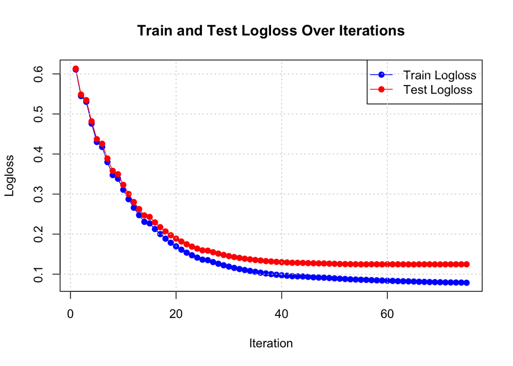

#### 3. ROC/AUC curve

**Figure 15**. ROC Curve for Gradient Boosting

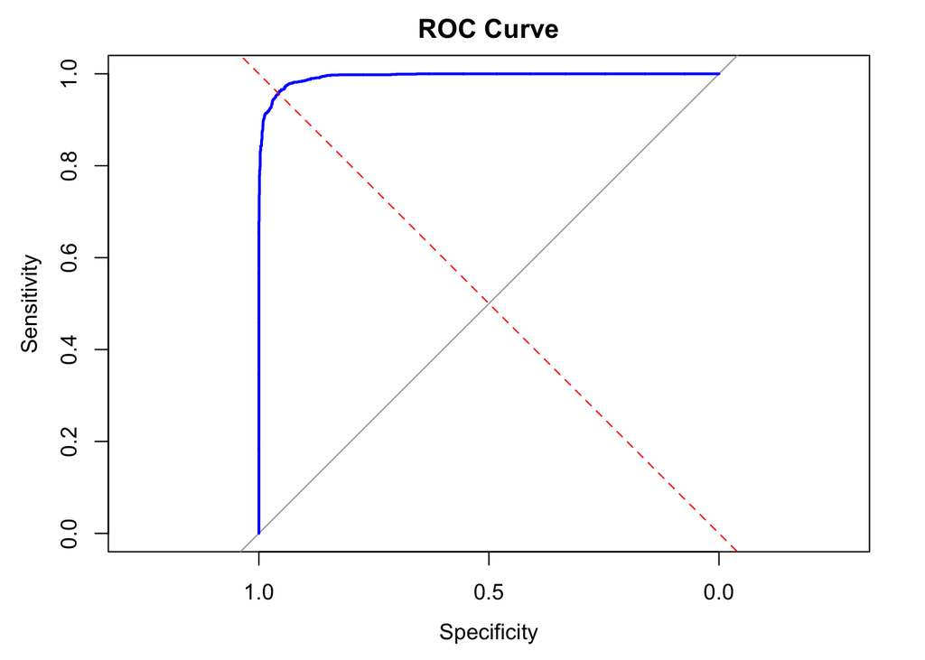

#### 4. Accuracy, precision and recall

Accuracy (%):95.82 Precision(%): 96 Recall(%):96.32

The model achieved strong overall performance, with an accuracy of 95.82%, precision of 96.00%, and recall of 96.32%. These metrics highlight the model’s reliability in predicting “High Installs” while effectively minimizing false positives and false negatives.

### Interpretability: Feature importance

**Figure 16**. Feature Importance of Gradient Boosting

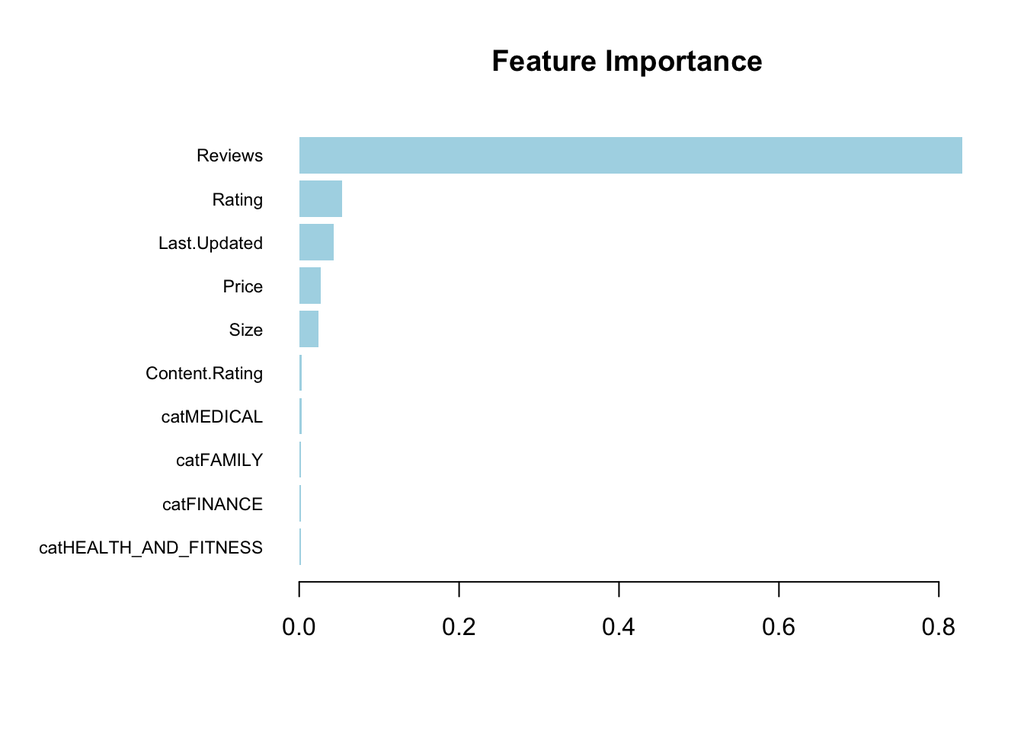

*Reviews Dominance:* The high importance of Reviews suggests that the number of reviews is strongly correlated with the success metric. It might reflect the popularity or credibility of an app.

*Secondary Factors:* Rating, Last.Updated, Price, and Size might provide additional predictive power but are not as influential as Reviews.

*Categories:* The low importance of categorical features (catMEDICAL, catFAMILY, etc.) indicates that these categories do not contribute much to the predictive task. This might be due to insufficient variance or weak correlation with the target variable.

## Support Vector Machine (SVM)

Support Vector Machines (SVM) are supervised learning models used for classification and regression tasks. For this dataset, a **linear SVM** model was chosen.

### Why SVM?

Unlike logistic regression, SVM incorporates the concept of a **soft margin**. This allows for some misclassification to improve generalization. While this increases bias, it reduces variance, making SVM particularly effective when the boundary between classes is not perfectly clear.

### Advantages

SVM models are versatile and can be adjusted using their parameters to control flexibility. This adaptability makes them suitable for a variety of datasets. In addition, SVMs are effective for handling high-dimensional data and are robust to overfitting, especially when using appropriate regularization.

### Parameters

The linear SVM model has a key parameter, **C**, which controls the trade-off between margin width and classification error.

- **Lower C values** create wider margins, allowing more misclassifications but increasing generalization.
- **Higher C values** create narrower margins, aiming for more accurate classification but potentially leading to overfitting.

**Figure 17**. Finding Optimal C using MSE

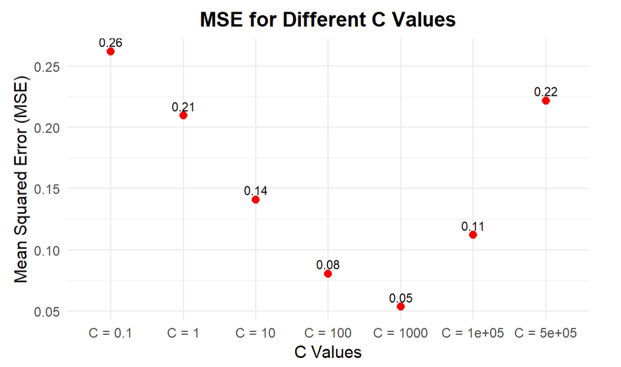

### Model Evaluation

#### 1. Confusion Matrix

**Figure 18**. Confusion Matrix

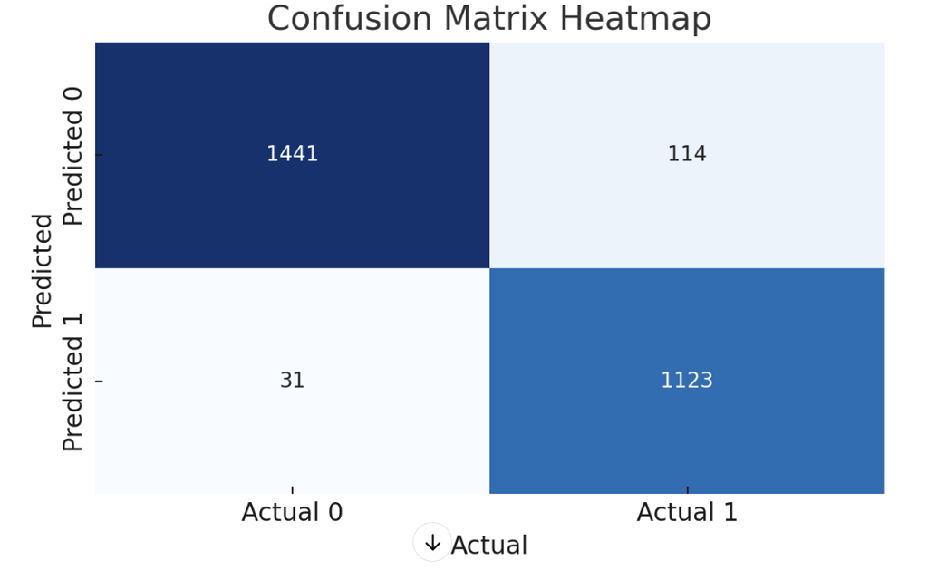

**Low Error Rates**: Off-diagonal elements (False Positives and False Negatives) are relatively small, suggesting minimal misclassification.

**Class Imbalance Impact**: A slightly higher number of True Negatives (1441) compared to True Positives (1123) may be attributed to a mild class imbalance, with slightly more instances belonging to class 0 than class 1.

#### 3. ROC

**Figure 19**. ROC Curve

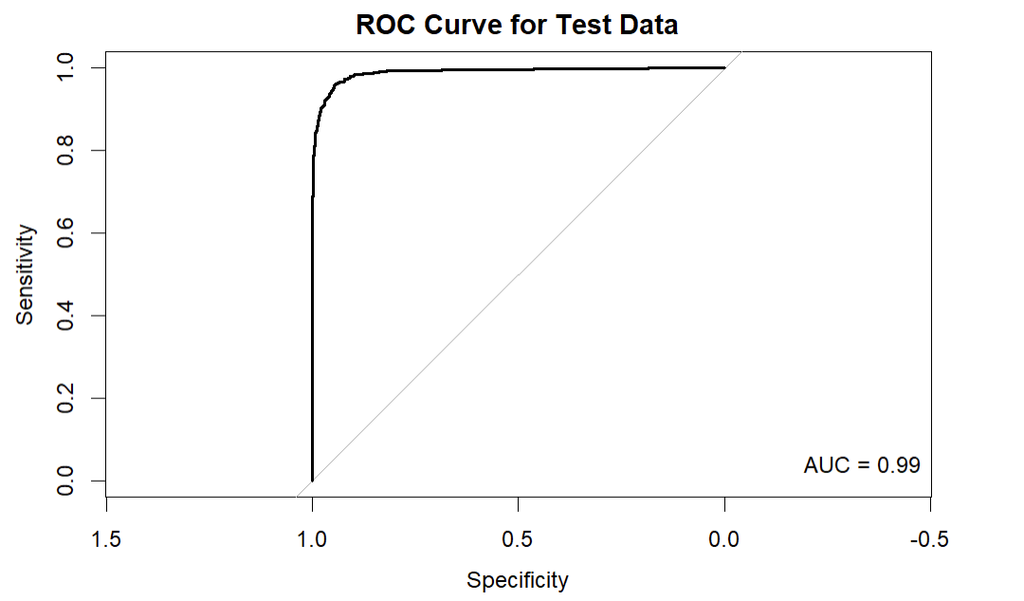

### Interpretability: Feature Importance

Apps with high installs tend to share features such as higher review counts and potentially other engagement metrics auch as ratings and active user feedback. These factors should be a focal point in marketing strategies to boost installs.

**Figure 20**. Top Categories

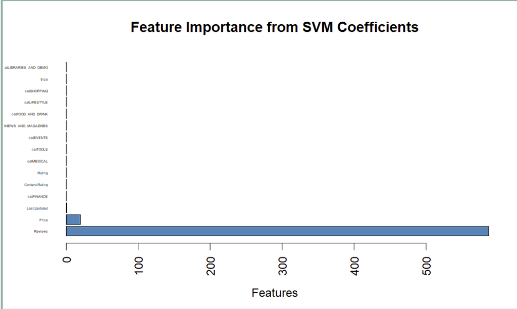

## **Overall**

The table below compares the performance of five machine learning models—Logistic Regression, KNN, Random Forest, Gradient Boost, and SVM—across various evaluation metrics, including Accuracy, Precision, Recall, F1 Score, and AUC-ROC Score. Gradient Boost emerges as the top-performing model in most categories, achieving the highest values for Accuracy (0.9581), Precision (0.96), F1 Score (0.96), and AUC-ROC Score (0.99), while SVM also performs exceptionally well, particularly in Recall (0.978) and AUC-ROC Score (0.99). Logistic Regression demonstrates strong performance, particularly with an AUC-ROC Score of 0.990 and a low overfitting tendency, alongside high interpretability. Random Forest shows robust results across all metrics but has a moderate overfitting tendency. In contrast, KNN lags behind the other models, showing lower scores across most metrics.

While Gradient Boost demonstrates better performance across several evaluation metrics, Logistic Regression proves to be a more suitable model for practical applications. This is attributed to the moderate overfitting tendency and moderate interpretability of Gradient Boost, which may limit its reliability in certain scenarios. In contrast, Logistic Regression exhibits a low tendency to overfit and offers high interpretability, making it a more robust and transparent choice for research and real-world implementation.

[output not shown]

# **Reliability and Limitations**

### Reliability

1. *Model Robustness:* The use of ensemble techniques like Random Forest and XGBoost enhances the reliability of predictions by aggregating multiple decision paths and reducing overfitting.
2. *Feature Importance*: All the models provide insights into feature importance, which adds transparency to the decision-making process.
3. *Balanced Data Representation:* Data cleaning and transformations, such as binning and log transformations, ensured a more balanced representation of key features, improving the reliability of model outputs.

### Limitations

1. *Dataset Size and Scope:* Although comprehensive, the dataset is limited to apps listed on the Google Play Store between 2010 and 2018, potentially omitting recent trends and app categories.
2. *Imputed Data:* The imputation of missing values, while necessary, may introduce bias or inaccuracies in the analysis.
3. *Static Analysis:* The study does not consider temporal trends, such as changes in user preferences or technological advancements over time.
4. *Model Limitations:* Despite their strengths, models like Random Forest and XGBoost can be computationally intensive and may lack interpretability compared to simpler methods like Logistic Regression.

# **Future Work**

1. Incorporate Temporal Dynamics: Future research could include time-series analysis to capture evolving trends in app success and user preferences.
2. Advanced Feature Engineering: Explore additional features, such as user demographics, sentiment analysis of reviews, and app update frequency.
3. Explainable AI: Implement interpretability techniques, such as SHAP values, to provide deeper insights into model predictions and improve stakeholder trust.
4. Real-Time Prediction: Develop pipelines for real-time prediction and monitoring of app success metrics using streaming data.

# **Conclusion**

Developers and stakeholders can leverage these insights to make data-driven decisions and prioritize features and strategies that have the greatest impact on driving app installs. Enhancing user reviews and ratings is crucial for building trust and credibility among users, while optimizing app size ensures smooth downloads and seamless usage, improving user experience. Additionally, adopting a low-pricing strategy can help attract a broader user base, making the app more accessible and appealing in competitive markets.

Furthermore, focusing on high-importance categories such as Games, Medical, Entertainment, Finance, and Photography can significantly improve market traction. These categories have proven to be particularly influential in determining app success, offering greater opportunities for user engagement and growth. By aligning their efforts with these findings, developers can better meet user expectations, enhance overall app performance, and gain a competitive advantage in the rapidly evolving app marketplace.

# **References**

P.Charuza[Online].Available: https://fueled.com/blog/much- money-can-earn-app [Accessed 19 Nov 2018].

“kaggle”[Online].Available:https://www.kaggle.com/lava18/goo gle-play-store-apps [Accessed 16 Nov 2018].

Y. Tian, M. Nagappan, D. Lo, and A. E. Hassan, “What are the charac- teristics of high-rated apps? a case study on free android applications,” in Software Maintenance and Evolution (ICSME), 2015 IEEE International Conference on, Sept 2015, pp. 301–310.

L.Guerrouj,S.Azad,andP.C.Rigby,“Theinfluenceofappchurnonapp success and stackoverflow discussions,” in 2015 IEEE 22nd International Conference on Software Analysis, Evolution, and Reengineering (SANER), March 2015, pp. 321–330.